# Taux d’investissement de l’Espagne

2023-03-15

# Introduction

## Contexte historique

Au cours des années 1970, l’Espagne a connu une période de croissance économique rapide, marquée par une augmentation du taux d’investissement dans le pays. Cependant, cette croissance a été tempérée par la crise pétrolière de 1973, qui a eu un impact négatif sur l’économie espagnole.

En 1977 le pacte de la Moncloa permet de faire remonter la pente de l’économie espagnole avec un dévelopement fort de l’investissement privé.

Fin des années 79 et début des années 1980, l’Espagne a subi le second choc pétrolier, qui a entraîné une baisse importante du taux d’investissement dans le pays. L’intégration à la Communauté Economique Européenne (CEE) puis du système monétaire Européen permit à l’Espagne d’améliorer sa situation économique fin des années 80.

Au début des années 90, l’Espagne fit face à une crise de confiance envers son économie faisant ralentir sa croissance, l’Espagne a ensuite connu une croissance économique soutenue, grace à certaines décisions politiques tel que la réforme de l’emploi. Cette période de croissance fut interrompue par la crise financière mondiale de 2008, qui a entraîné une baisse importante du taux d’investissement en Espagne.

Depuis lors, l’Espagne a connu une période de reprise économique, marquée par une augmentation progressive du taux d’investissement dans le pays. Cependant, le taux d’investissement en Espagne reste inférieur à celui des autres grandes économies européennes, notamment l’Allemagne et la France.

### Génération des données et statistiques déscriptives de l’investissement

```
##    Min. 1st Qu.  Median    Mean 3rd Qu.    Max.
##   461.9   870.7  1788.0  2077.9  3116.6  4385.7
```

### Chronograme de l’investissement

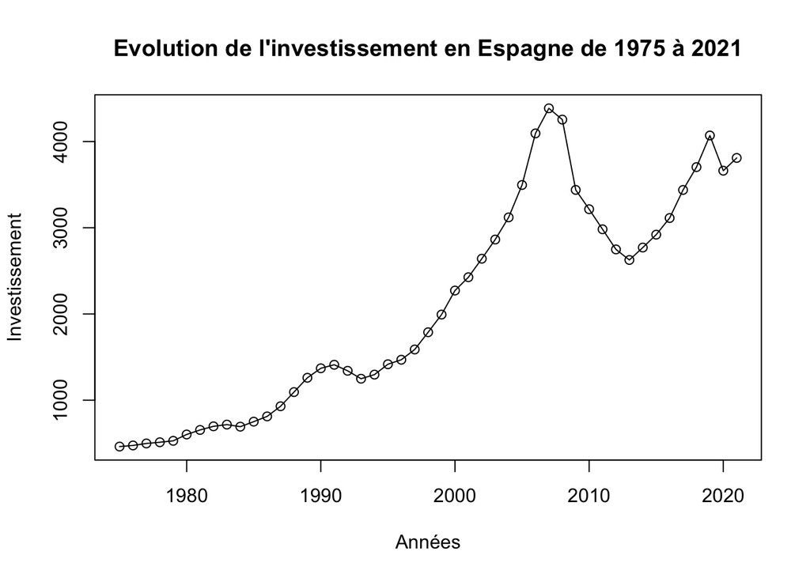

```r
plot.ts(X, main = "Evolution de l'investissement en Espagne de 1975 à 2021", ylab = "Investissement", xlab = "Années", type = "o")
```

Sur ce graphique nous pouvons observer l’augmentation de l’investissement entre 1975 et 2021.

### Statistiques déscriptives du taux d’investissement

```
##    Min. 1st Qu.  Median    Mean 3rd Qu.    Max.
##  0.1736  0.2044  0.2242  0.2295  0.2561  0.3003
```

### Chronogramme du taux d’investissement

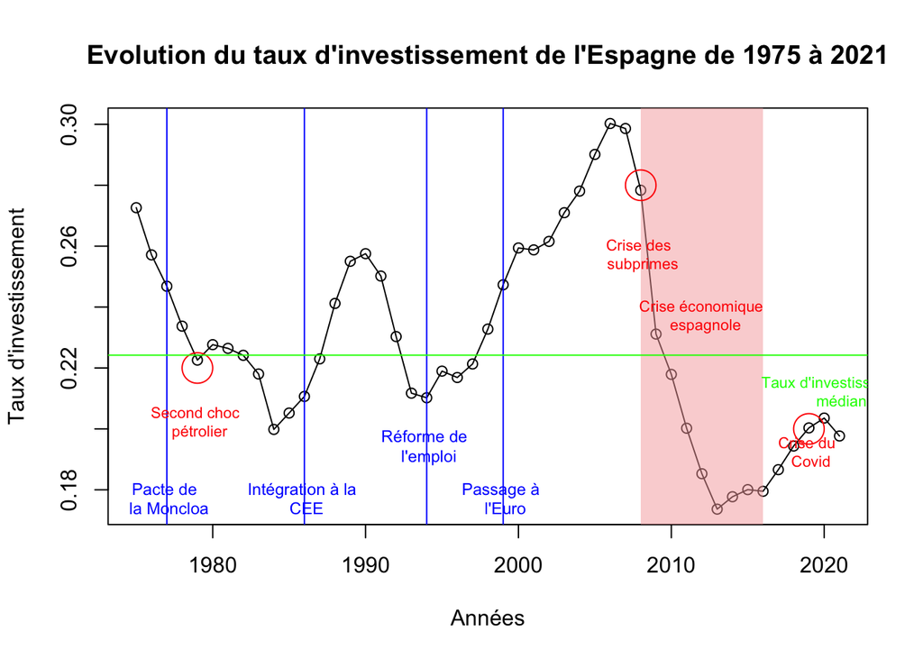

La série présente une tendance décroissante sur la période, de plus la variance est indépendante du temps donc notre série est homoscédastique. Nous retrouvons bien les résultats évoqués dans l’introduction sur ce chronograme, avec les moments de chutes du taux d’investissement causé principalement par le second choc pétrolier et la crise des subprimes. On observe que le taux d’investissement peine à rejoindre la médiane de la série EN 2020.

# Stationnarité

On va chercher à savoir si le PGD de notre série est stationnaire

### ACF

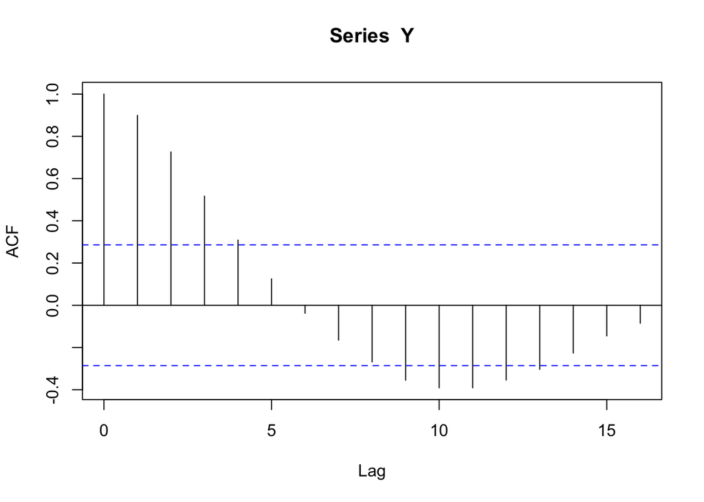

```r
library(urca)
acf(Y)
```

D’après l’ACF nous avons $\rho(1), \rho(2), \rho(3), \rho(4), \rho(9), \rho(10), \rho(11), \rho(12), \rho(13)$ de significatifs et donc présentant des corrélations.

### PACF

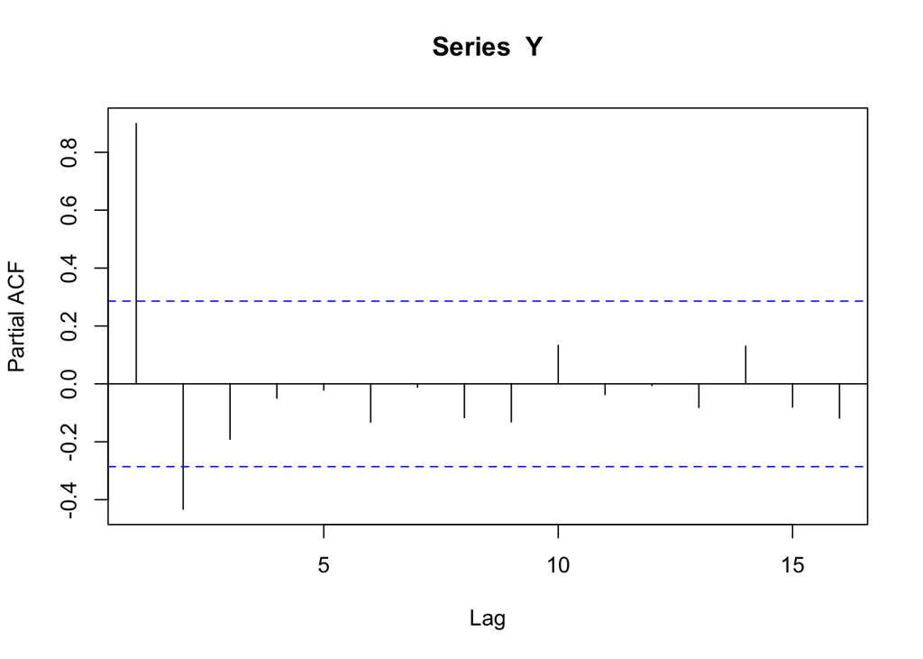

```r
pacf(Y)
```

D’après la PACF il n’ya que le premier et le deuxième $\rho$ de significatif.

### Test de racine unitaire

#### Test de Dickey-Fuller

Après avoir rejeté la spécification “trend” et “drift”, on prendra la spécification “none”, on va estimer le modèle suivant:

$$\Delta X_t =
(\rho-1)X_{t-1}+\varepsilon_t$$

On cherche à tester l’hypothèse suivante :

- H$_0$ : $\rho -1 = 0$
- H$_1$ : $\mid \rho \mid < 1$

Si la statistique t pour ($\rho$-1) > -1.95 alors on accepte H0.

```r
summary(ur.df(Y,type="none",lag=0))
```

```
##
## ###############################################
## # Augmented Dickey-Fuller Test Unit Root Test #
## ###############################################
##
## Test regression none
##
##
## Call:
## lm(formula = z.diff ~ z.lag.1 - 1)
##
## Residuals:
##       Min        1Q    Median        3Q       Max
## -0.044852 -0.008885  0.002722  0.009178  0.020120
##
## Coefficients:
##          Estimate Std. Error t value Pr(>|t|)
## z.lag.1 -0.008552   0.007959  -1.075    0.288
##
## Residual standard error: 0.01255 on 45 degrees of freedom
## Multiple R-squared:  0.02502,    Adjusted R-squared:  0.003349
## F-statistic: 1.155 on 1 and 45 DF,  p-value: 0.2883
##
##
## Value of test-statistic is: -1.0745
##
## Critical values for test statistics:
##       1pct  5pct 10pct
## tau1 -2.62 -1.95 -1.61
```

-1.075 > -1.95 Donc on accepte H0($\rho - 1 = 0$), donc d’après Dickey-Fuller la série est DS et présence d’une racine unitaire.

On va chercher a savoir si il y’a de l’autocorrélation dans les résidus afin de valider le résultat précédent.

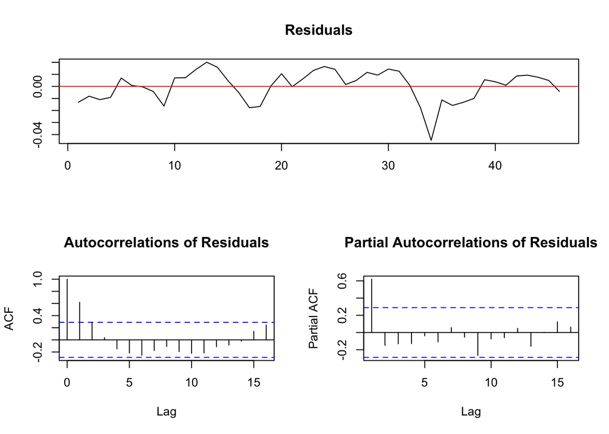

Il y a de l’autocorrélation et de l’autocorrélation partielle dans les résidus du modèle donc les résultats de Dickey-Fuller sont invalides, on va donc réaliser le test de Dickey-Fuller augmenté afin de prendre en compte cette autocorrélation.

#### Test de Dickey-Fuller augmenté

La nouvelle spécification du modèle devient (au retard $p$)
$$X_t =
(\rho-1) X_{t-1} + \beta_0 + \beta_1 tendance_t +
\sum_{j=1}^p\gamma_j\Delta_{X_{t-j}} + \varepsilon_t$$

```r
pmax = as.integer(12*(length(Y)/100)^(0.25)) #formue de schwert
summary(CADFtest(Y, criterions="MAIC", type="none", max.lag.y=pmax))
```

```
## Augmented DF test
##                                              ADF test
## t-test statistic:                          -0.3969816
## p-value:                                    0.5339276
## Max lag of the diff. dependent variable:    9.0000000
##
## Call:
## dynlm(formula = formula(model), start = obs.1, end = obs.T)
##
## Residuals:
##       Min        1Q    Median        3Q       Max
## -0.026808 -0.007190  0.000802  0.007365  0.017636
##
## Coefficients:
##             Estimate Std. Error t value Pr(>|t|)
## L(y, 1)    -0.003051   0.007685  -0.397  0.53393
## L(d(y), 1)  0.644599   0.179106   3.599  0.00127 **
## L(d(y), 2) -0.069168   0.217121  -0.319  0.75251
## L(d(y), 3) -0.111981   0.216637  -0.517  0.60943
## L(d(y), 4) -0.020276   0.214784  -0.094  0.92549
## L(d(y), 5) -0.086390   0.211750  -0.408  0.68650
## L(d(y), 6) -0.175660   0.209529  -0.838  0.40919
## L(d(y), 7)  0.080745   0.210302   0.384  0.70402
## L(d(y), 8)  0.090078   0.213634   0.422  0.67662
## L(d(y), 9) -0.260359   0.175920  -1.480  0.15045
## ---
## Signif. codes:  0 '***' 0.001 '**' 0.01 '*' 0.05 '.' 0.1 ' ' 1
##
## Residual standard error: 0.0107 on 27 degrees of freedom
## Multiple R-squared:  0.5036, Adjusted R-squared:  0.3197
## F-statistic: 3.037 on 9 and 27 DF,  p-value: 0.01216
```

Le nombre de retards à ajouter dans la régression pour tenir compte de l’autocorrélation est de 9 avec le MAIC.

Nous avons supprimer tout les $\gamma$ non significatifs, à la fin nous ne retrouvons plus qu’un retard.

```r
summary(ur.df(Y,type="none",lag=1))
```

```
##
## ###############################################
## # Augmented Dickey-Fuller Test Unit Root Test #
## ###############################################
##
## Test regression none
##
##
## Call:
## lm(formula = z.diff ~ z.lag.1 - 1 + z.diff.lag)
##
## Residuals:
##       Min        1Q    Median        3Q       Max
## -0.033676 -0.005439  0.000500  0.008359  0.017373
##
## Coefficients:
##             Estimate Std. Error t value Pr(>|t|)
## z.lag.1    -0.003779   0.006377  -0.593    0.557
## z.diff.lag  0.617260   0.116440   5.301 3.76e-06 ***
## ---
## Signif. codes:  0 '***' 0.001 '**' 0.01 '*' 0.05 '.' 0.1 ' ' 1
##
## Residual standard error: 0.009857 on 43 degrees of freedom
## Multiple R-squared:  0.4056, Adjusted R-squared:  0.3779
## F-statistic: 14.67 on 2 and 43 DF,  p-value: 1.39e-05
##
##
## Value of test-statistic is: -0.5926
##
## Critical values for test statistics:
##       1pct  5pct 10pct
## tau1 -2.62 -1.95 -1.61
```

Avec Dickey-Fuller et 1 explicatives supplémentaire, on accepte H0($\rho - 1 = 0$) avec -0.5926 > -1.95, donc la série est DS.

On vérifie que nous avons bien éliminé l’autocorrélation:

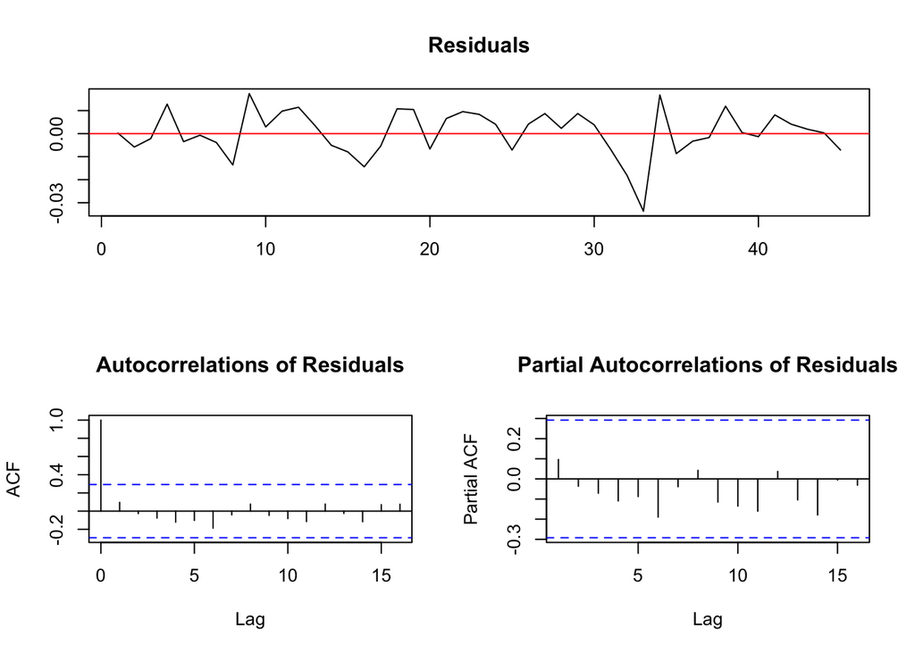

```r
plot(ur.df(Y,type="none",lag=1))
```

#### Test de Zivot et Andrews

Le modèle est le suivant:

$$X_t = \beta_0 + \beta_1t + \rho X_{t-1}
+ \delta_1 DU_t(T_B) + \delta_2 DT_t(T_B) +
\sum_{j=1}^p\gamma_j\Delta_{X_{t-j}} + \varepsilon_t$$

On test:

H0: $\rho = 1$ (Ds sans changement structurel)

Ha: $\mid \rho \mid < 1$ (TS avec un unique changement structurel)

```r
summary(ur.za(Y, model = "intercept", lag=pmax-9))
```

```
##
## ################################
## # Zivot-Andrews Unit Root Test #
## ################################
##
##
## Call:
## lm(formula = testmat)
##
## Residuals:
##       Min        1Q    Median        3Q       Max
## -0.022745 -0.003696  0.001092  0.006003  0.016108
##
## Coefficients:
##               Estimate Std. Error t value Pr(>|t|)
## (Intercept)  0.0523112  0.0124570   4.199 0.000136 ***
## y.l1         0.7235315  0.0539635  13.408  < 2e-16 ***
## trend        0.0008172  0.0001756   4.655 3.24e-05 ***
## du          -0.0365467  0.0060461  -6.045 3.43e-07 ***
## ---
## Signif. codes:  0 '***' 0.001 '**' 0.01 '*' 0.05 '.' 0.1 ' ' 1
##
## Residual standard error: 0.009317 on 42 degrees of freedom
##   (1 observation effacée parce que manquante)
## Multiple R-squared:  0.9248, Adjusted R-squared:  0.9195
## F-statistic: 172.2 on 3 and 42 DF,  p-value: < 2.2e-16
##
##
## Teststatistic: -5.1232
## Critical values: 0.01= -5.34 0.05= -4.8 0.1= -4.58
##
## Potential break point at position: 34
```

Nous prenons la spécification “intercept” car DT n’est pas significatif avec 1 retard.

La date de rupture est la 34éme observation.

La statistique t = -5.12 < -4.8 on rejette H0, la série est TS avec un unique changement structurel.

#### Test de Lee et Strazich

On va maintenant chercher à tester s’il y a un changement structurel, avec $2$ `breaks` possibles. Dans l’équation :

$$\Delta y_t = \delta' \Delta Z_t +
\phi (y_{t-1} - \psi_X - Z_{t-1}\delta') + u_t$$

On teste l’hypothèse suivante :

- H$_0$ : $\phi = 0$ (DS avec date de rupture dans la constante)
- H$_1$ : $\phi \neq 0$ (TS avec un changement structurel)

Nous prenons lag = 4 pour éviter les problèmes d’inversion de matrices.

##### LS avec une date de rupture

```
## [[1]]
## [1] -3.197045
##
## [1] "First possible structural break at position: 30"
## [1] "The location of the first break - lambda_1: 0.6 , with the number of total observations: 47"
## Critical values - Break model:
##      lambda    1%    5%   10%
## [1,]    0.1 -5.11 -4.50 -4.21
## [2,]    0.2 -5.07 -4.47 -4.20
## [3,]    0.3 -5.15 -4.45 -4.18
## [4,]    0.4 -5.05 -4.50 -4.18
## [5,]    0.5 -5.11 -4.51 -4.17
## [1] "Number of lags used: 4"
## Runtime:
## Time difference of 0.0066998 mins
```

La statsitique calculée: -3.19

La valeur critique au seuil de 5% étant supérieur à la statistique calculé on a: -3.19 > -4.51 donc on accepte H0, donc le processus qui a généré la série est DS avec une date de rupture.

##### LS avec deux dates de ruptures

```r
myBreaks = 2
myModel = "break"
myLags <- 4
cl <- makeCluster(max(1, detectCores() - 1))
registerDoSNOW(cl)
myParallel_LS <- ur.ls.bootstrap(y=Y , model = myModel, breaks = myBreaks, lags = myLags, method = "Fixed", pn = 0.1, critval = "bootstrap", print.results = "print")
```

```
## [[1]]
## [1] -5.049338
##
## [1] "First possible structural break at position: 27"
## [1] "The location of the first break - lambda_1: 0.6 , with the number of total observations: 47"
## [1] "Second possible structural break at position: 35"
## [1] "The location of the second break - lambda_2: 0.7 , with the number of total observations: 47"
## Critical values:
##               Break 2 - 0.4 - 1% Break 2 - 0.4 - 5% Break 2 - 0.4 - 10%
## Break 1 - 0.2              -6.16              -5.59               -5.27
## Break 1 - 0.4                 NA                 NA                  NA
## Break 1 - 0.6                 NA                 NA                  NA
##               Break 2 - 0.6 - 1% Break 2 - 0.6 - 5% Break 2 - 0.6 - 10%
## Break 1 - 0.2              -6.41              -5.74               -5.32
## Break 1 - 0.4              -6.45              -5.67               -5.31
## Break 1 - 0.6                 NA                 NA                  NA
##               Break 2 - 0.8 - 1% Break 2 - 0.8 - 5% Break 2 - 0.8 - 10%
## Break 1 - 0.2              -6.33              -5.71               -5.33
## Break 1 - 0.4              -6.42              -5.65               -5.32
## Break 1 - 0.6              -6.32              -5.73               -5.32
## [1] "Number of lags used: 4"
## Runtime:
## Time difference of 0.01777915 mins
```

Nous retiendrons alors comme résultat que la série est DS avec une date de rupture.

# PGD de la série différencié

## Stationnarisation

On peut transformer une série issue d’un processus DS en processus stationnaire en la différenciant.

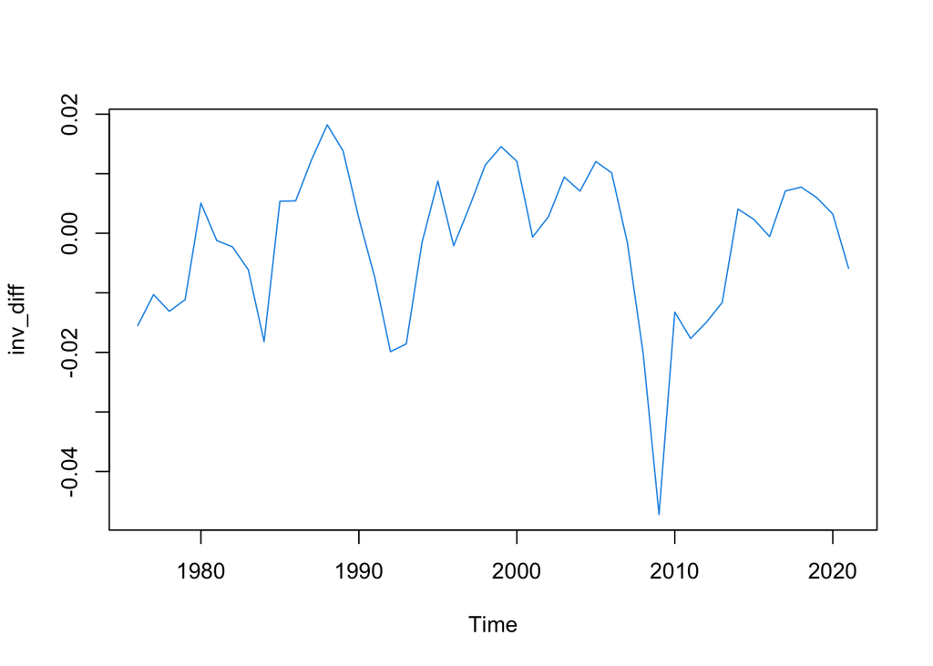

```r
inv_diff = diff(Y)
plot(inv_diff,type='l',col=4)
```

Le taux d’investissement à une tendance constante, il n’y a pas non plus d’homscédasticité.

## Test de Dickey-Fuller

Après avoir tester et rejetter les spécifications “trend” et “drift”, nous garderons la spécification “none”.

```r
summary(ur.df(inv_diff,type="none",lag=0))
```

```
##
## ###############################################
## # Augmented Dickey-Fuller Test Unit Root Test #
## ###############################################
##
## Test regression none
##
##
## Call:
## lm(formula = z.diff ~ z.lag.1 - 1)
##
## Residuals:
##       Min        1Q    Median        3Q       Max
## -0.034592 -0.006176 -0.000199  0.007445  0.016740
##
## Coefficients:
##         Estimate Std. Error t value Pr(>|t|)
## z.lag.1   -0.376      0.115  -3.269   0.0021 **
## ---
## Signif. codes:  0 '***' 0.001 '**' 0.01 '*' 0.05 '.' 0.1 ' ' 1
##
## Residual standard error: 0.009784 on 44 degrees of freedom
## Multiple R-squared:  0.1954, Adjusted R-squared:  0.1771
## F-statistic: 10.69 on 1 and 44 DF,  p-value: 0.002099
##
##
## Value of test-statistic is: -3.269
##
## Critical values for test statistics:
##       1pct  5pct 10pct
## tau1 -2.62 -1.95 -1.61
```

La statistique t calculé pour ($\rho - 1$) = -3.269 < -1.95, donc on rejette H0; $\rho - 1$ est alors différent de 0.

Donc la série est stationnaire.

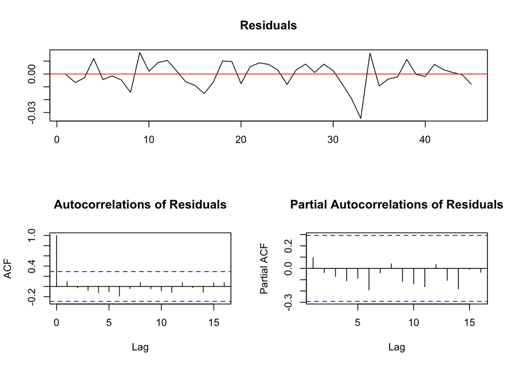

```r
plot(ur.df(inv_diff,type="none",lag=0))
```

Nous n’observons pas la présence d’autocorrélation dans les aléas, nous indiquant que l’autocorrélation est bien prise en compte par notre modèle.

Ainsi nous pouvons alors valider le résultat de stationnarité de la série différencié du taux d’investissement.

# Estimation

## Autocorrélation

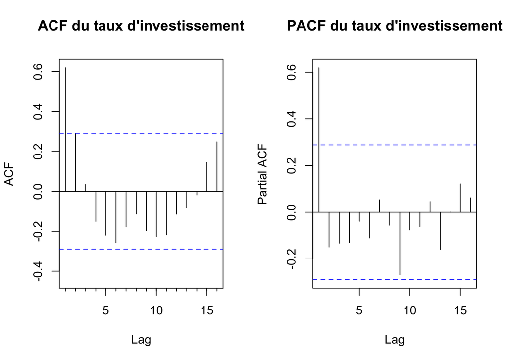

```r
par(mfrow=c(1,2))
Acf(inv_diff, main="ACF du taux d'investissement")
pacf(inv_diff, main="PACF du taux d'investissement")
```

On observe de l’autocorrélation partiel à l’ordre 1.

## Test de ljung-box

- H$_0$ : $\rho(1) = \rho(2) = \dots = \rho(K) =0$
- H$_1$ : Au moins un des $\rho(k) \neq 0$

La statistique de test utilisée est :
$$Q_K = T(T+1) \sum_{k=1}^{K}
\frac{\hat\rho(k)^2}{T-k}$$

```r
Box.test(inv_diff, lag = 1, type ="Ljung-Box")
```

```
##
##  Box-Ljung test
##
## data:  inv_diff
## X-squared = 18.802, df = 1, p-value = 1.451e-05
```

La pvalue est inférieur à 0.05.

On rejette H0, on peut donc admettre qu’il y a de l’autocorrélation dans nos données à l’ordre 1.

## EACF

```r
library(TSA)
eacf(inv_diff)
```

```
## AR/MA
##   0 1 2 3 4 5 6 7 8 9 10 11 12 13
## 0 x o o o o o o o o o o  o  o  o
## 1 o o o o o o o o o o o  o  o  o
## 2 x o o o o o o o o o o  o  o  o
## 3 x x o o o o o o o o o  o  o  o
## 4 x x o o o o o o o o o  o  o  o
## 5 x o o o o o o o o o o  o  o  o
## 6 x o o o o o o o o o o  o  o  o
## 7 x o x o x o o o o o o  o  o  o
```

Nous pouvons faire un ARMA(1,0), (0,1) et (1,1) d’après l’eacf.

```r
library(forcats)
reg1 = Arima(inv_diff, order=c(2,0,1), include.mean = FALSE)
library(lmtest)
coeftest(reg1)
```

```
##
## z test of coefficients:
##
##     Estimate Std. Error z value  Pr(>|z|)
## ar1  1.56179    0.11587 13.4789 < 2.2e-16 ***
## ar2 -0.66905    0.10707 -6.2487 4.139e-10 ***
## ma1 -0.94900    0.10692 -8.8755 < 2.2e-16 ***
## ---
## Signif. codes:  0 '***' 0.001 '**' 0.01 '*' 0.05 '.' 0.1 ' ' 1
```

Nous avons bien tout les coefficients de significatifs.

## Estimation des aléas

### Test de Jarques-Berra

On va tester:

H0: La variable aléatoire est normalement distribué

Ha: La variable aléatoire n’est pas normalement distribué

Avec:
$$JB = \frac{n-k}{6}\times (S^2 +
\frac{(K-2)^2}{4})$$

```r
jarque.bera.test(reg1$res)
```

```
##
##  Jarque Bera Test
##
## data:  reg1$res
## X-squared = 1.7069, df = 2, p-value = 0.4259
```

La pvalue 0.4259 > 0.05 donc on accepte H0, les aléas sont nomalement distribués.

### Test de student

On va tester:

H0: L’espérance des aléas est nulle

Ha: L’espérance des aléas n’est pas nulle

Avec:
$$t = \frac{\mid m(e)
\mid}{\sigma_e} \times \sqrt{T}$$

```r
t.test(reg1$residuals)
```

```
##
##  One Sample t-test
##
## data:  reg1$residuals
## t = -1.273, df = 45, p-value = 0.2096
## alternative hypothesis: true mean is not equal to 0
## 95 percent confidence interval:
##  -0.004450985  0.001003568
## sample estimates:
##    mean of x
## -0.001723708
```

```r
standres=(reg1$res-mean(reg1$res))/sd(reg1$res)
Box.test(standres,type="Ljung-Box",lag=15)
```

```
##
##  Box-Ljung test
##
## data:  standres
## X-squared = 6.3562, df = 15, p-value = 0.9731
```

La p-value est supérieur à 5% donc on ne rejette pas H0.

Le modèle à donc réussit à prendre en compte l’autocorrélation.

Donc l’espérance des aléas est nulles et il n’y a pas d’autocorrélation des aléas (grace au test de Ljung-Box sur les aléas standardisés avec un lag de 15).

### Test d’Engle

On va tester:

H0: $a_{1} = a_{2} = .. = a_{p} = 0$

Ha: $a_{1} \neq 0$

```r
ArchTest(standres, lag=12)
```

```
##
##  ARCH LM-test; Null hypothesis: no ARCH effects
##
## data:  standres
## Chi-squared = 10.11, df = 12, p-value = 0.6063
```

0.60 > 0.05 donc on accepte H0, il n’y a pas d’effet ARCH ni de cluster de volatilité sur les donnés.

Les aléas sont alors bien des bruits blancs, nous pouvons alors utiliser le modèle afin de faire des inférences.

# Prévision

```r
BIC(reg1)
```

```
## [1] -283.6936
```

Le critére d’information Bayésien de notre modèle vaut -283.69.

```r
prev = forecast(reg1, h=4, level=0.95)
prev
```

```
##      Point Forecast       Lo 95      Hi 95
## 2022   -0.001692824 -0.02043980 0.01705416
## 2023    0.001292738 -0.02069824 0.02328371
## 2024    0.003151565 -0.01949482 0.02579795
## 2025    0.004057191 -0.01860085 0.02671523
```

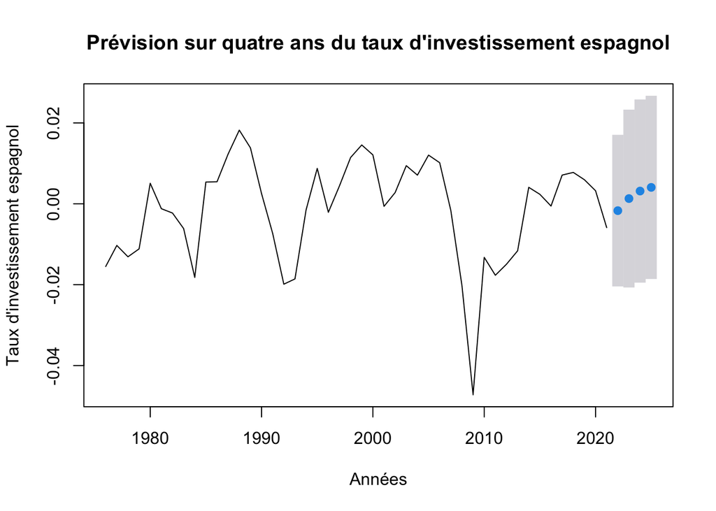

```r
plot(prev, lwd=1, main="Prévision sur quatre ans du taux d'investissement espagnol", ylab="Taux d'investissement espagnol", xlab="Années")
```

Les résidus étant des bruits blancs nous pouvons utiliser la valeur de l’intervalle de confiance pour les prévisions.

Plus on avance dans le temps et plus la prévision est incertaine.

# Annexe

## Dickey-Fuller spécification trend

```r
summary(ur.df(Y,type="trend",lag=0))
```

```
##
## ###############################################
## # Augmented Dickey-Fuller Test Unit Root Test #
## ###############################################
##
## Test regression trend
##
##
## Call:
## lm(formula = z.diff ~ z.lag.1 + 1 + tt)
##
## Residuals:
##       Min        1Q    Median        3Q       Max
## -0.041339 -0.008964  0.002082  0.006709  0.019007
##
## Coefficients:
##               Estimate Std. Error t value Pr(>|t|)
## (Intercept)  1.814e-02  1.494e-02   1.214    0.231
## z.lag.1     -8.361e-02  5.882e-02  -1.421    0.162
## tt          -2.233e-05  1.451e-04  -0.154    0.878
##
## Residual standard error: 0.01259 on 43 degrees of freedom
## Multiple R-squared:  0.04605,    Adjusted R-squared:  0.001682
## F-statistic: 1.038 on 2 and 43 DF,  p-value: 0.3629
##
##
## Value of test-statistic is: -1.4215 0.9488 1.0379
##
## Critical values for test statistics:
##       1pct  5pct 10pct
## tau3 -4.15 -3.50 -3.18
## phi2  7.02  5.13  4.31
## phi3  9.31  6.73  5.61
```

On accepte H0 avec $\beta1$ = 0

On rejette également le test de Dickey Fuller avec la spécification drift

```r
summary(ur.df(Y,type="drift",lag=0))
```

```
##
## ###############################################
## # Augmented Dickey-Fuller Test Unit Root Test #
## ###############################################
##
## Test regression drift
##
##
## Call:
## lm(formula = z.diff ~ z.lag.1 + 1)
##
## Residuals:
##       Min        1Q    Median        3Q       Max
## -0.041690 -0.008541  0.001773  0.006590  0.019259
##
## Coefficients:
##             Estimate Std. Error t value Pr(>|t|)
## (Intercept)  0.01706    0.01303   1.309    0.197
## z.lag.1     -0.08118    0.05604  -1.449    0.155
##
## Residual standard error: 0.01245 on 44 degrees of freedom
## Multiple R-squared:  0.04553,    Adjusted R-squared:  0.02383
## F-statistic: 2.099 on 1 and 44 DF,  p-value: 0.1545
##
##
## Value of test-statistic is: -1.4487 1.4434
##
## Critical values for test statistics:
##       1pct  5pct 10pct
## tau2 -3.58 -2.93 -2.60
## phi1  7.06  4.86  3.94
```

## Dickey-Fuller augmenté avec 9 explicatives,

```r
summary(ur.df(Y,type="none",lag=9))
```

```
##
## ###############################################
## # Augmented Dickey-Fuller Test Unit Root Test #
## ###############################################
##
## Test regression none
##
##
## Call:
## lm(formula = z.diff ~ z.lag.1 - 1 + z.diff.lag)
##
## Residuals:
##       Min        1Q    Median        3Q       Max
## -0.026808 -0.007190  0.000802  0.007365  0.017636
##
## Coefficients:
##              Estimate Std. Error t value Pr(>|t|)
## z.lag.1     -0.003051   0.007685  -0.397  0.69450
## z.diff.lag1  0.644599   0.179106   3.599  0.00127 **
## z.diff.lag2 -0.069168   0.217121  -0.319  0.75251
## z.diff.lag3 -0.111981   0.216637  -0.517  0.60943
## z.diff.lag4 -0.020276   0.214784  -0.094  0.92549
## z.diff.lag5 -0.086390   0.211750  -0.408  0.68650
## z.diff.lag6 -0.175660   0.209529  -0.838  0.40919
## z.diff.lag7  0.080745   0.210302   0.384  0.70402
## z.diff.lag8  0.090078   0.213634   0.422  0.67662
## z.diff.lag9 -0.260359   0.175920  -1.480  0.15045
## ---
## Signif. codes:  0 '***' 0.001 '**' 0.01 '*' 0.05 '.' 0.1 ' ' 1
##
## Residual standard error: 0.0107 on 27 degrees of freedom
## Multiple R-squared:  0.5036, Adjusted R-squared:  0.3197
## F-statistic: 2.739 on 10 and 27 DF,  p-value: 0.01813
##
##
## Value of test-statistic is: -0.397
##
## Critical values for test statistics:
##       1pct  5pct 10pct
## tau1 -2.62 -1.95 -1.61
```

Le dernier coefficient n’est pas significatif donc nous ne pouvons pas conserver ce modèle.

## Test de ZA

avec lag = 9:

```r
summary(ur.za(Y, model = "both", lag=pmax))
```

```
##
## ################################
## # Zivot-Andrews Unit Root Test #
## ################################
##
##
## Call:
## lm(formula = testmat)
##
## Residuals:
##        Min         1Q     Median         3Q        Max
## -0.0164501 -0.0024061 -0.0000631  0.0038701  0.0163236
##
## Coefficients:
##               Estimate Std. Error t value Pr(>|t|)
## (Intercept)  0.1831700  0.0497163   3.684 0.001228 **
## y.l1         0.1314371  0.2296059   0.572 0.572573
## trend        0.0009629  0.0003953   2.436 0.023021 *
## y.dl1        0.9165531  0.1730333   5.297 2.24e-05 ***
## y.dl2        0.4436252  0.2200962   2.016 0.055672 .
## y.dl3        0.3729691  0.2192747   1.701 0.102441
## y.dl4        0.4489280  0.2170296   2.069 0.050015 .
## y.dl5        0.2495745  0.2001191   1.247 0.224900
## y.dl6        0.0696690  0.1803332   0.386 0.702800
## y.dl7        0.1880996  0.1694450   1.110 0.278431
## y.dl8        0.1797535  0.1753645   1.025 0.316011
## y.dl9       -0.0351108  0.1724957  -0.204 0.840498
## du           0.0314576  0.0113794   2.764 0.011034 *
## dt          -0.0059275  0.0015351  -3.861 0.000793 ***
## ---
## Signif. codes:  0 '***' 0.001 '**' 0.01 '*' 0.05 '.' 0.1 ' ' 1
##
## Residual standard error: 0.008343 on 23 degrees of freedom
##   (10 observations effacées parce que manquantes)
## Multiple R-squared:  0.9654, Adjusted R-squared:  0.9459
## F-statistic: 49.43 on 13 and 23 DF,  p-value: 1.179e-13
##
##
## Teststatistic: -3.7828
## Critical values: 0.01= -5.57 0.05= -5.08 0.1= -4.82
##
## Potential break point at position: 30
```

avec lag = 1 et both:

```r
summary(ur.za(Y, model = "both", lag=1))
```

```
##
## ################################
## # Zivot-Andrews Unit Root Test #
## ################################
##
##
## Call:
## lm(formula = testmat)
##
## Residuals:
##        Min         1Q     Median         3Q        Max
## -0.0171034 -0.0039270  0.0003741  0.0042981  0.0204368
##
## Coefficients:
##               Estimate Std. Error t value Pr(>|t|)
## (Intercept)  0.0503278  0.0122806   4.098 0.000204 ***
## y.l1         0.7541299  0.0564074  13.369  3.8e-16 ***
## trend        0.0004961  0.0001993   2.490 0.017148 *
## y.dl1        0.4545016  0.1353499   3.358 0.001763 **
## du          -0.0233159  0.0080877  -2.883 0.006380 **
## dt          -0.0001285  0.0008066  -0.159 0.874208
## ---
## Signif. codes:  0 '***' 0.001 '**' 0.01 '*' 0.05 '.' 0.1 ' ' 1
##
## Residual standard error: 0.008256 on 39 degrees of freedom
##   (2 observations effacées parce que manquantes)
## Multiple R-squared:  0.9442, Adjusted R-squared:  0.9371
## F-statistic: 132.1 on 5 and 39 DF,  p-value: < 2.2e-16
##
##
## Teststatistic: -4.3588
## Critical values: 0.01= -5.57 0.05= -5.08 0.1= -4.82
##
## Potential break point at position: 34
```

DT n’est pas significatif nous sommes obligés de passer à la spécification “intercept”.

## Modèles non retenues

MA(1)

```r
library(forcats)
reg2 = Arima(inv_diff, order=c(0,2,1))
library(lmtest)
coeftest(reg2)
```

```
##
## z test of coefficients:
##
##      Estimate Std. Error z value  Pr(>|z|)
## ma1 -1.000000   0.064119 -15.596 < 2.2e-16 ***
## ---
## Signif. codes:  0 '***' 0.001 '**' 0.01 '*' 0.05 '.' 0.1 ' ' 1
```

ARMA(1,1)

```r
library(forcats)
reg3 = Arima(inv_diff, order=c(1,2,1))
library(lmtest)
coeftest(reg3)
```

```
##
## z test of coefficients:
##
##      Estimate Std. Error  z value Pr(>|z|)
## ar1 -0.030389   0.152133  -0.1998   0.8417
## ma1 -0.999999   0.064660 -15.4654   <2e-16 ***
## ---
## Signif. codes:  0 '***' 0.001 '**' 0.01 '*' 0.05 '.' 0.1 ' ' 1
```

AR(1)

```r
library(forcats)
reg4 = Arima(inv_diff, order=c(1,2,0))
library(lmtest)
coeftest(reg4)
```

```
##
## z test of coefficients:
##
##     Estimate Std. Error z value  Pr(>|z|)
## ar1 -0.46518    0.13123 -3.5448 0.0003929 ***
## ---
## Signif. codes:  0 '***' 0.001 '**' 0.01 '*' 0.05 '.' 0.1 ' ' 1
```

On ne conserve pas ce modèle car les aléas sont anormalement distribués:

```r
jarque.bera.test(reg4$res)
```

```
##
##  Jarque Bera Test
##
## data:  reg4$res
## X-squared = 82.159, df = 2, p-value < 2.2e-16
```

En effet on rejette H0 avec la pvalue inférieur à 0.05.